# ALY6040 M5 - Final Project Draft Report

Instructor: Dr. Marcus Ellis

Student: Shahabaddin Feghahati

Completion Date: 03/26/2023

#### Introduction

This study aims to develop and evaluate Support Vector Machine (SVM) models for predicting the “STATUS” variable based on other variables in a dataset. The code uses the “caret” package in R to clean and preprocess the data, perform exploratory data analysis, and train SVM models using the SMOTE algorithm to balance the target class. The code trains two SVM models with linear and radial kernels, respectively, and evaluates their performance on test data using confusion matrices. It then defines a 10-fold cross-validation scheme to train a radial SVM model, tunes its hyperparameters using a grid search with five values, and evaluates its performance on test data using a confusion matrix. The libraries used in this code include data.table, e1071, caret, dplyr, ggplot2, gridExtra, and DMwR.

```r
library(data.table)
credit_data <- fread("credit_application.csv")

# Remove the FLAG_MOBIL column
credit_data <- subset(credit_data, select = -FLAG_MOBIL)

# remove rows with NAs
credit_data <- na.omit(credit_data)

# convert categorical variables to numerical representation
credit_data[, `:=`(
  CODE_GENDER = as.integer(factor(CODE_GENDER, levels = c("M", "F"), labels = c(1, 0))),
  FLAG_OWN_CAR = as.integer(factor(FLAG_OWN_CAR, levels = c("Y", "N"), labels = c(1, 0))),
  FLAG_OWN_REALTY = as.integer(factor(FLAG_OWN_REALTY, levels = c("Y", "N"), labels = c(1, 0))),
  NAME_INCOME_TYPE = as.integer(factor(NAME_INCOME_TYPE)),
  NAME_EDUCATION_TYPE = as.integer(factor(NAME_EDUCATION_TYPE)),
  NAME_FAMILY_STATUS = as.integer(factor(NAME_FAMILY_STATUS)),
  NAME_HOUSING_TYPE = as.integer(factor(NAME_HOUSING_TYPE)),
  #FLAG_MOBIL = as.integer(factor(FLAG_MOBIL)),
  FLAG_WORK_PHONE = as.integer(factor(FLAG_WORK_PHONE)),
  FLAG_PHONE = as.integer(factor(FLAG_PHONE)),
  OCCUPATION_TYPE = as.integer(factor(OCCUPATION_TYPE))
)]

# encode target variable as factor and convert to numerical representation
credit_data[, STATUS := as.integer(factor(STATUS, levels = c("C", "X", "0", "1", "2", "3", "4", "5")))]

# Check the distribution of the target variable
table(credit_data$STATUS)
```

```
##
##      1      2      3      4      5      6      7      8
## 225994 101970 200603   6392    542    181    152   1087
```

```r
# check the first few rows of the modified data table
#head(credit_data)
```

The given distribution of the target variable ‘STATUS’ in the credit card dataset is imbalanced, as there are a significantly larger number of observations in some categories compared to others. Specifically, categories 1 and 3 (Paid off that month and Payment delayed for 1-29 days) make up the majority of the observations, while categories 4-8 (Payment delayed for 30-59 days, Payment delayed for 60-89 days, Payment delayed for 90-119 days, Payment delayed for 120-149 days, Payment delayed for 150 days or more) have much smaller numbers of observations.

Imbalanced data can create issues for predictive modeling and machine learning algorithms, as these models tend to perform poorly on rare events, and can be biased towards the majority class. Therefore, in situations where imbalanced data is encountered, various techniques such as oversampling, undersampling, or synthetic sampling can be used to balance the data and improve the performance of the predictive models.

##### Correlation-based Feature Selection in Credit Data Analysis

```r
# load required libraries
library(data.table)
library(e1071)

# calculate the correlation coefficients
#correlations <- cor(preproc_data)
correlations <- cor(credit_data)

# filter out variables with low correlation coefficients
high_corr_vars <- names(which(abs(correlations[, "STATUS"]) > 0.01))

# remove the target variable from the list of high correlation variables
high_corr_vars <- high_corr_vars[high_corr_vars != "STATUS"]

# create a new data table with the high correlation variables and the target variable
selected_vars <- c(high_corr_vars, "STATUS")
selected_data <- credit_data[, selected_vars, with = FALSE]
str(selected_data)
```

```
## Classes 'data.table' and 'data.frame':   536921 obs. of  10 variables:
##  $ AMT_INCOME_TOTAL    : num  112500 112500 112500 112500 112500 ...
##  $ NAME_INCOME_TYPE    : int  5 5 5 5 5 5 5 5 5 5 ...
##  $ NAME_FAMILY_STATUS  : int  2 2 2 2 2 2 2 2 2 2 ...
##  $ FLAG_PHONE          : int  1 1 1 1 1 1 1 1 1 1 ...
##  $ FLAG_EMAIL          : int  0 0 0 0 0 0 0 0 0 0 ...
##  $ YEARS_EMPLOYED      : num  3.1 3.1 3.1 3.1 3.1 ...
##  $ log_YEARS_EMPLOYED  : num  1.13 1.13 1.13 1.13 1.13 ...
##  $ log_AMT_INCOME_TOTAL: num  11.6 11.6 11.6 11.6 11.6 ...
##  $ MONTHS_BALANCE      : int  -28 -6 -29 0 -4 -12 -7 -5 -11 -20 ...
##  $ STATUS              : int  3 1 2 1 1 2 2 1 3 3 ...
##  - attr(*, ".internal.selfref")=<externalptr>
```

The code above loads the required libraries and performs correlation-based feature selection on a credit data set. The selected variables are filtered out based on a threshold value of correlation coefficients and a new data table is created with only the high correlation variables and the target variable. The resulting data table has 536921 observations and 10 variables, including variables related to income, family status, phone and email flags, employment years, log-transformed variables, and the target variable ‘STATUS’.

##### Apply standardization to the credit_data dataset

```r
# Load the necessary packages
library(caret)    # for data pre-processing
library(dplyr)    # for data manipulation

selected_data_ <- selected_data[, c("AMT_INCOME_TOTAL", "NAME_INCOME_TYPE", "NAME_FAMILY_STATUS", "FLAG_PHONE", "FLAG_EMAIL",
                                "YEARS_EMPLOYED", "log_YEARS_EMPLOYED", "log_AMT_INCOME_TOTAL", "MONTHS_BALANCE")]

# Create a pre-processing recipe for standardization
preproc_recipe <- preProcess(selected_data_, method = c("center", "scale"))

# Apply the pre-processing recipe to the selected_data
preproc_data <- predict(preproc_recipe, selected_data_)

# Add STATUS back to the pre-processed data
preproc_data$STATUS <- selected_data$STATUS
```

##### Split the data into training and testing sets while handling the imbalanced dataset

```r
library(caret)

# Set the seed for reproducibility
set.seed(123)

# Split the data into 80% training and 20% testing sets, with stratified sampling based on "STATUS"
train_idx <- createDataPartition(preproc_data$STATUS, p = 0.8, list = FALSE, times = 1)

# Create the training and testing sets
train_data <- preproc_data[train_idx, ]
test_data <- preproc_data[-train_idx, ]
```

The code above splits the preprocessed data into training and testing sets, using stratified sampling based on the target variable ‘STATUS’. The training set contains 80% of the data and is stored as ‘train_data’, while the testing set contains 20% of the data and is stored as ‘test_data’.

##### Create a bar chart that shows the class distribution of the STATUS variable in the training and testing sets

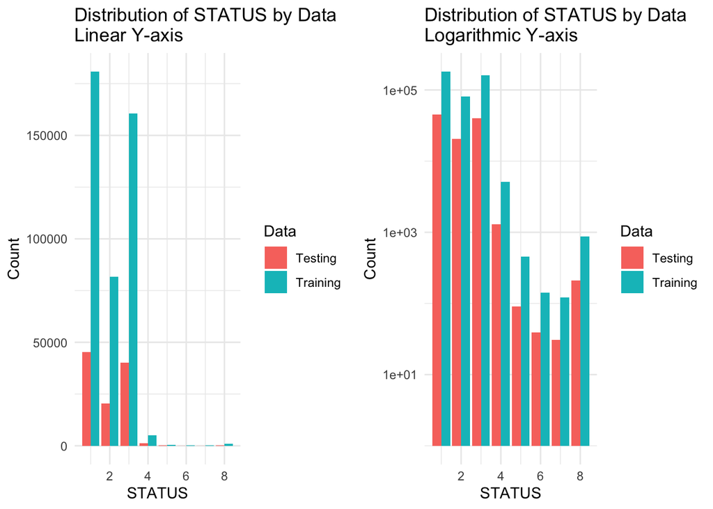

```r
library(ggplot2)
library(gridExtra)

# Combine the training and testing sets for plotting
combined_data <- rbind(train_data, test_data)

# Create a factor variable to specify the training/testing status of each observation
combined_data$Data <- ifelse(row.names(combined_data) %in% row.names(train_data), "Training", "Testing")
combined_data$Data <- as.factor(combined_data$Data)

# Linear Y-axis plot
plot1 <- ggplot(combined_data, aes(x = STATUS, fill = Data)) +
  geom_bar(position = "dodge") +
  labs(title = "Distribution of STATUS by Data\nLinear Y-axis", x = "STATUS", y = "Count") +
  theme_minimal() +
  scale_y_continuous(trans = "identity")

# Logarithmic Y-axis plot
plot2 <- ggplot(combined_data, aes(x = STATUS, fill = Data)) +
  geom_bar(position = "dodge") +
  labs(title = "Distribution of STATUS by Data\nLogarithmic Y-axis", x = "STATUS", y = "Count") +
  theme_minimal() +
  scale_y_continuous(trans = "log10")

# Combine plots side by side
grid.arrange(plot1, plot2, ncol = 2)
```

In both the training and testing sets, class 1 has the highest frequency, followed by class 3 and then class 2. Classes 4 to 8 have much lower frequencies than the first three classes.

These class frequencies can provide some insights into the distribution of the target variable and the balance of the dataset. It appears that the dataset is imbalanced, with classes 1, 2, and 3 having much higher frequencies than the other classes. This may need to be taken into account when developing a predictive model, as it could affect the performance of the model. Techniques such as oversampling or undersampling can be used to balance the dataset and improve the model’s performance.

It is generally recommended to perform oversampling or any other data preprocessing steps after splitting the data into training and testing sets. This is because oversampling the minority class(es) before splitting the data can result in the same observations being present in both the training and testing sets.

Having the same observations in both the training and testing sets can lead to overfitting and unrealistic estimates of model performance. Therefore, it is important to ensure that the training and testing sets are independent and identically distributed.

In the code provided earlier, oversampling is applied to the train_data dataset after it has been split from the original data using createDataPartition. This helps ensure that the oversampled data is used only for training the model, and that the testing set is not influenced by the oversampling process.

```r
# Convert the response variable to a factor variable
train_data$STATUS <- as.factor(train_data$STATUS)
test_data$STATUS <- as.factor(test_data$STATUS)
```

```r
# Load the necessary packages
#installed.packages('DMwR')
#install.packages(c('xts', 'quantmod', 'ROCR'))
#install.packages ( "/Users/sf/Downloads/DMwR_0.4.1.tar.gz", repos=NULL, type="source", dependencies = TRUE)

library(DMwR)

# Check the distribution of the target variable
table(train_data$STATUS)
```

```
##
##      1      2      3      4      5      6      7      8
## 180803  81569 160483   5091    452    142    121    878
```

```r
# Over-sample the minority classes using SMOTE
train_data_balanced <- SMOTE(STATUS ~ ., train_data, perc.over = 1500, k = 8)

# Perform undersampling to balance the dataset
#train_data_balanced <- downSample(x = train_data[, -10], y = train_data[, 10])
#train_data_balanced <- downSample(formula = STATUS ~ ., data = train_data, yname = "STATUS")
#train_data_balanced <- cbind(train_data_balanced$x, STATUS = train_data_balanced$y)

# Apply ADASYN algorithm to balance the dataset
#train_data_balanced <- adasyn(train_data[, -STATUS], train_data$STATUS)

# Check the distribution of the target variable after balancing
table(train_data_balanced$STATUS)
```

```
##
##    1    2    3    4    5    6    7    8
## 1529  682 1372   31    2    2 1936   12
```

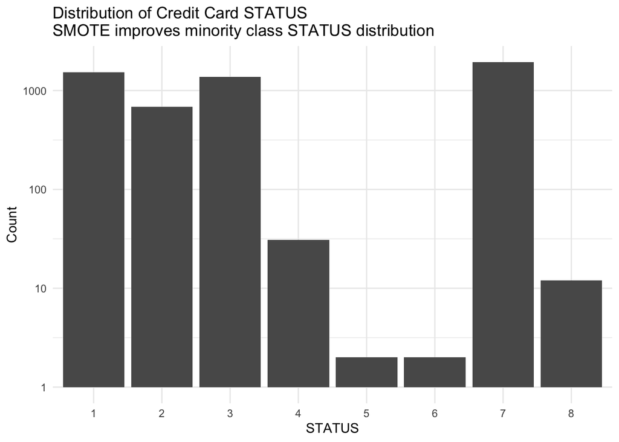

```r
# Create the bar chart
ggplot(data = train_data_balanced, aes(x = STATUS)) +
  geom_bar() +
  labs(title = "Distribution of Credit Card STATUS\nSMOTE improves minority class STATUS distribution", x = "STATUS", y = "Count") +
  scale_y_continuous(trans = "log10") +
  theme_minimal()
```

Here, perc.over is the percentage of oversampling, and k is the number of nearest neighbors to consider when generating synthetic samples. The result you provided shows the count of each class in the train_data_balanced dataset after applying SMOTE oversampling.

##### Train SVM model with linear kernel and cost 10 for multi-class classification

```r
# Load the caret package
library(caret)

# Train SVM model using multi-class approach
svm_model <- svm(STATUS ~ ., data = train_data_balanced, kernel = "linear", cost = 10)

# Predict on test data
svm_pred <- predict(svm_model, newdata = test_data)

# Confusion matrix
confusionMatrix(svm_pred, test_data$STATUS)
```

```
## Confusion Matrix and Statistics
##
##           Reference
## Prediction     1     2     3     4     5     6     7     8
##          1 22350  8413 14795   486    23     9     8    76
##          2     0     0     0     0     0     0     0     0
##          3  5819  3794  8301   227    15    10     2    15
##          4     0     0     0     0     0     0     0     0
##          5     0     0     0     0     0     0     0     0
##          6     0     0     0     0     0     0     0     0
##          7 17022  8194 17024   588    52    20    21   118
##          8     0     0     0     0     0     0     0     0
##
## Overall Statistics
##
##                Accuracy : 0.2856
##                  95% CI : (0.2829, 0.2883)
##     No Information Rate : 0.4208
##     P-Value [Acc > NIR] : 1
##
##                   Kappa : 0.0547
##
##  Mcnemar's Test P-Value : NA
##
## Statistics by Class:
##
##                      Class: 1 Class: 2 Class: 3 Class: 4  Class: 5  Class: 6
## Sensitivity            0.4946     0.00   0.2069  0.00000 0.0000000 0.0000000
## Specificity            0.6171     1.00   0.8531  1.00000 1.0000000 1.0000000
## Pos Pred Value         0.4842      NaN   0.4565      NaN       NaN       NaN
## Neg Pred Value         0.6269     0.81   0.6433  0.98788 0.9991619 0.9996368
## Prevalence             0.4208     0.19   0.3736  0.01212 0.0008381 0.0003632
## Detection Rate         0.2081     0.00   0.0773  0.00000 0.0000000 0.0000000
## Detection Prevalence   0.4299     0.00   0.1693  0.00000 0.0000000 0.0000000
## Balanced Accuracy      0.5559     0.50   0.5300  0.50000 0.5000000 0.5000000
##                       Class: 7 Class: 8
## Sensitivity          0.6774194 0.000000
## Specificity          0.5992771 1.000000
## Pos Pred Value       0.0004879      NaN
## Neg Pred Value       0.9998446 0.998054
## Prevalence           0.0002887 0.001946
## Detection Rate       0.0001956 0.000000
## Detection Prevalence 0.4008027 0.000000
## Balanced Accuracy    0.6383482 0.500000
```

The data above includes 8 levels of credit status, where level 1 indicates that the payment was made on time, level 2 indicates that there was no loan for the month, and Levels 3-8 of the credit status variable indicate the degree to which a payment has been delayed. Specifically, level 3 indicates that a payment was delayed for 1-29 days, level 4 indicates a delay of 30-59 days, level 5 indicates a delay of 60-89 days, level 6 indicates a delay of 90-119 days, level 7 indicates a delay of 120-149 days, and level 8 indicates a delay of 150 days or more. These levels reflect the severity and duration of late payments, which can have a negative impact on a borrower’s credit score and overall creditworthiness.

To potentially improve the SVM model, some general suggestions include feature engineering to better capture patterns in the data, hyperparameter tuning to find optimal kernel functions and hyperparameters, cross-validation to estimate generalization performance and prevent overfitting, ensembling to combine multiple models and reduce overfitting risk, and selecting relevant evaluation metrics such as precision, recall, F1-score, or ROC AUC depending on the problem context.

##### Train SVM model with radial kernel and cost 40 for multi-class classification

```r
# Train SVM model using multi-class approach
svm_model <- svm(STATUS ~ ., data = train_data_balanced, kernel = "radial", cost = 40)

# Predict on test data
svm_pred <- predict(svm_model, newdata = test_data)

# Confusion matrix
confusionMatrix(svm_pred, test_data$STATUS)
```

```
## Confusion Matrix and Statistics
##
##           Reference
## Prediction     1     2     3     4     5     6     7     8
##          1 26352  9869 18328   589    30     7     8    57
##          2  2342  1561  2357    84     4     2     1     7
##          3 10402  6105 13996   435    26     5     5    44
##          4    71    55    88     6     0     0     0     0
##          5     0     0     0     0     0     0     0     0
##          6     0     0     0     0     0     0     0     0
##          7  6018  2809  5334   187    30    25    17    91
##          8     6     2    17     0     0     0     0    10
##
## Overall Statistics
##
##                Accuracy : 0.3906
##                  95% CI : (0.3877, 0.3935)
##     No Information Rate : 0.4208
##     P-Value [Acc > NIR] : 1
##
##                   Kappa : 0.0826
##
##  Mcnemar's Test P-Value : NA
##
## Statistics by Class:
##
##                      Class: 1 Class: 2 Class: 3  Class: 4  Class: 5  Class: 6
## Sensitivity            0.5831  0.07652   0.3489 4.612e-03 0.0000000 0.0000000
## Specificity            0.5355  0.94485   0.7469 9.980e-01 1.0000000 1.0000000
## Pos Pred Value         0.4770  0.24552   0.4512 2.727e-02       NaN       NaN
## Neg Pred Value         0.6387  0.81351   0.6579 9.879e-01 0.9991619 0.9996368
## Prevalence             0.4208  0.18999   0.3736 1.212e-02 0.0008381 0.0003632
## Detection Rate         0.2454  0.01454   0.1303 5.588e-05 0.0000000 0.0000000
## Detection Prevalence   0.5144  0.05921   0.2889 2.049e-03 0.0000000 0.0000000
## Balanced Accuracy      0.5593  0.51068   0.5479 5.013e-01 0.5000000 0.5000000
##                       Class: 7  Class: 8
## Sensitivity          0.5483871 4.785e-02
## Specificity          0.8649850 9.998e-01
## Pos Pred Value       0.0011715 2.857e-01
## Neg Pred Value       0.9998493 9.981e-01
## Prevalence           0.0002887 1.946e-03
## Detection Rate       0.0001583 9.313e-05
## Detection Prevalence 0.1351344 3.259e-04
## Balanced Accuracy    0.7066860 5.238e-01
```

##### Train SVM model with 10-fold cross-validation and radial kernel

```r
# Load the necessary libraries
library(caret)

# Define the cross-validation scheme
folds <- createFolds(train_data_balanced$STATUS, k = 10)

# Define the SVM model using multi-class approach
svm_model <- train(
  STATUS ~ .,
  data = train_data_balanced,
  method = "svmRadial",
  trControl = trainControl(method = "cv", index = folds),
  tuneLength = 5
)

# Predict on test data
svm_pred <- predict(svm_model, newdata = test_data)

# Confusion matrix
confusionMatrix(svm_pred, test_data$STATUS)
```

```
## Confusion Matrix and Statistics
##
##           Reference
## Prediction     1     2     3     4     5     6     7     8
##          1 26871 10184 18976   609    30    12    11    87
##          2   252   281   395    16     0     0     0     0
##          3  7655  5058 11548   345    21     5     3    16
##          4    21     5     6     3     0     0     0     0
##          5     0     0     0     0     0     0     0     0
##          6     0     0     0     0     0     0     0     0
##          7 10392  4873  9191   328    39    22    17   103
##          8     0     0     4     0     0     0     0     3
##
## Overall Statistics
##
##                Accuracy : 0.3606
##                  95% CI : (0.3577, 0.3635)
##     No Information Rate : 0.4208
##     P-Value [Acc > NIR] : 1
##
##                   Kappa : 0.0733
##
##  Mcnemar's Test P-Value : NA
##
## Statistics by Class:
##
##                      Class: 1 Class: 2 Class: 3  Class: 4  Class: 5  Class: 6
## Sensitivity            0.5946 0.013774   0.2878 2.306e-03 0.0000000 0.0000000
## Specificity            0.5191 0.992378   0.8052 9.997e-01 1.0000000 1.0000000
## Pos Pred Value         0.4732 0.297669   0.4685 8.571e-02       NaN       NaN
## Neg Pred Value         0.6380 0.810970   0.6546 9.879e-01 0.9991619 0.9996368
## Prevalence             0.4208 0.189985   0.3736 1.212e-02 0.0008381 0.0003632
## Detection Rate         0.2502 0.002617   0.1075 2.794e-05 0.0000000 0.0000000
## Detection Prevalence   0.5288 0.008791   0.2296 3.259e-04 0.0000000 0.0000000
## Balanced Accuracy      0.5568 0.503076   0.5465 5.010e-01 0.5000000 0.5000000
##                       Class: 7  Class: 8
## Sensitivity          0.5483871 1.435e-02
## Specificity          0.7676035 1.000e+00
## Pos Pred Value       0.0006810 4.286e-01
## Neg Pred Value       0.9998301 9.981e-01
## Prevalence           0.0002887 1.946e-03
## Detection Rate       0.0001583 2.794e-05
## Detection Prevalence 0.2324878 6.519e-05
## Balanced Accuracy    0.6579953 5.072e-01
```

#### CONCLUSION

Therefore, some recommendations for next actions are:

- Explore other classification models (decision trees, random forests, neural networks) for better accuracy and sensitivity.
- Evaluate impact of feature engineering and selection on model performance.
- Gather more or diverse data to train more robust models.
- Fine-tune hyperparameters to optimize performance.
- Consider using ensemble of models for better overall performance.

#### REFERENCES

Chen, C., Härdle, W., & Unwin, A. (2007). *Handbook of data visualization.* Springer.

Hastie, T., Tibshirani, R., & Friedman, J. (2009). *The Elements of Statistical Learning Data Mining, Inference, and Prediction* (Second Edition.). Springer New York. https://doi.org/10.1007/978-0-387-84858-7

Kabacoff, R. (2015). *R in action: data analysis and graphics with R* (Second edition.). Manning Publications.

Run R code online. (n.d.). Retrieved March 2, 2023, from https://rdrr.io/snippets/